# Replication archive for ‘Incentives can spur Covid-19 vaccination uptake’

Heike Klüver, Humboldt

Felix Hartmann, Humboldt

Macartan Humphreys, WZB and Columbia

Ferdinand Geißler, Humboldt

Johannes Giesecke, Humboldt

July 2021

## Housekeeping

```r
knitr::opts_chunk$set(echo=TRUE, warning=FALSE, message=FALSE, comment=NA)
options(qwraps2_markup = "markdown")
```

Code chunk uses `pacman` to install and load all packages.

### Packages

```r
if (!require(pacman)) install.packages("pacman")

pacman::p_load(
  rgdal,       # geo data
  geojsonsf,   # read json
  rgeos,       # geo data
  sf,          # geo data
  gridExtra,   # plot arrange
  gtrendsR,    # google trends
  aod,         # hypothesis testing (1.3.1)
  car,         # linear hypothesis testing for causal tree (3.0-2)
  corrplot,    # Correlations (0.84)
  DeclareDesign,
  dplyr,       # Data manipulation (0.8.0.1)
  evtree,      # evolutionary learning of globally optimal trees (1.0-7)
  fastDummies,
  fBasics,     # Summary statistics (3042.89)
  ggplot2,
  ggpubr,
  grf,         # Generalized random forests (0.10.2)
  haven,       # load sav
  interplot,   # Interactions plotting
  kableExtra,  # Prettier RMarkdown (1.0.1)
  knitr,
  labelled,
  psych,       # Correlation p-values (1.8.12)
  purrr,
  rpart,       # Classification and regression trees, or CART (4.1-13)
  reshape2,
  rpart.plot,  # Plotting trees (3.0.6)
  readr,       # Reading csv files (1.3.1)
  sjlabelled,
  stats,
  summarytools,
  texreg,
  tidyverse,
  tidyselect,
  tidyr,       # Database operations (0.8.3)
  treeClust,   # Predicting leaf position for causal trees (1.1-7)
  tibble)      # Modern alternative to data frames (2.1.1)

# Number of trees for causal forests
N_trees = 1000

# Set seed for reproducibility
set.seed(201911)
```

### Paths

Code chunk provides paths for pulling data and saving figures and tables.

```r
datapath <- "../../../../4_data/wave_1/D-P21-13185 HU Berlin Impfskeptiker_Finaler_Datensatz.sav"

# PNAS figures
fig_1_AB_path <- "../PNAS_revision/figures/fig_1_AB.pdf"
fig_2_ABC_path <- "../PNAS_revision/figures/fig_2_ABC.pdf"


# Interim figures
fig_1_path <- "../PNAS_revision/figures/figure_1.pdf"
fig_2_path <- "../PNAS_revision/figures/figure_2.pdf"
fig_3_path <- "../PNAS_revision/figures/figure_3.pdf"
fig_4_path <- "../PNAS_revision/figures/figure_4.pdf"
google_plot_path <- "../PNAS_revision/figures/figure_5.pdf"
corr_matrix_plot_path <- "../PNAS_revision/figures/figure_6.pdf"
correlates_plot_path  <- "../PNAS_revision/figures/figure_7.pdf"
undecided_cf_path     <- "../PNAS_revision/figures/figure_8.pdf"
blps_plot_path <- "../PNAS_revision/figures/figure_9.pdf"
lm_plot_path <- "../PNAS_revision/figures/figure_10.pdf"
fig_11_path <- "../PNAS_revision/figures/figure_11.pdf"
age_fig_path <- "../PNAS_revision/figures/figure_12.pdf"

tab_1_path <- "../PNAS_revision/figures/table_1.tex"
tab_2_path <- "../PNAS_revision/figures/table_2.tex"
tab_3_path <- "../PNAS_revision/figures/table_3.tex"

# variable names and labels
var_list <- read.csv("input/vars.csv") %>% arrange(order)

covariate_names <- var_list$new_name[var_list$covariate==1]

# Labels for treatments
treatments <- treatment_levels <- c("financialA","financialB", "negative", "transaction")
treatment_levels_diff <- c("financialA_diff","financialB_diff", "negative_diff", "transaction_diff")
treatment_labels <- c("Financial 25", "Financial 50", "Freedoms", "Local Doctors")

statuses <- c("Acceptant", "Refusals", "Undecided")


# Training fraction
train_fraction <- 1  # for causal forests: currently all data used
```

## Prepare Data

### Import data

Import data, get labels for treatment, rename variables, generate differences.

Raw data has treatments recorded in a single vector with 12 values. These are now transformed ino the underlying factors.

```r
# get labels
Z_labels <- read_sav(datapath) %>%
  pull(c_0031) %>% attr("labels") %>%
  names() %>% strsplit( "-") %>%
  lapply(function(x) data.frame(t(x))) %>% bind_rows() %>% mutate(Z_1_1 = 1:12) %>%
  mutate(negative_t1 = as.numeric(X1),
         transaction_t1 = as.numeric(X3),
         financialA_t1 = 1*(X2 =="1a"),
         financialB_t1 = 1*(X2 =="1b")) %>%
  dplyr::select(Z_1_1, negative_t1, financialA_t1, financialB_t1, transaction_t1)

kable(Z_labels, booktabs = TRUE)
```

| Z_1_1 | negative_t1 | financialA_t1 | financialB_t1 | transaction_t1 |
| --- | --- | --- | --- | --- |
| 1 | 0 | 0 | 0 | 0 |
| 2 | 0 | 0 | 0 | 1 |
| 3 | 0 | 1 | 0 | 0 |
| 4 | 0 | 0 | 1 | 0 |
| 5 | 1 | 0 | 0 | 0 |
| 6 | 1 | 0 | 0 | 1 |
| 7 | 1 | 1 | 0 | 1 |
| 8 | 1 | 0 | 1 | 1 |
| 9 | 0 | 1 | 0 | 1 |
| 10 | 0 | 0 | 1 | 1 |
| 11 | 1 | 1 | 0 | 0 |
| 12 | 1 | 0 | 1 | 0 |

```r
df <- read_sav(datapath) %>%
  rowid_to_column("ID")  %>%
  mutate(
    Z_1_1 = as.numeric(paste(c_0031)),
    outcome_t1 = v_74 / 10,
    Z_1_2 = as.numeric(paste(c_0032)),
    outcome_t2 = v_77 / 10
  ) %>%
  left_join(Z_labels) %>%
  left_join(
    Z_labels %>%
      rename(
        Z_1_2 = Z_1_1,
        negative_t2 = negative_t1,
        transaction_t2 = transaction_t1,
        financialA_t2 = financialA_t1,
        financialB_t2 = financialB_t1
      )
  ) %>%
#    mutate(distance_km = NA) %>%

  # rename covariates
  rename_at(
    vars(var_list$var_name[var_list$transformed==0 & var_list$new_name!="distance_km"]),
    ~ var_list$new_name[var_list$transformed==0 & var_list$new_name!="distance_km"]) %>%

  # transformations
  mutate(
    outcome_diff     = outcome_t2 - outcome_t1,
    negative_diff    = negative_t2 - negative_t1,
    financialA_diff  = financialA_t2 - financialA_t1,
    financialB_diff  = financialB_t2 - financialB_t1,
    transaction_diff = transaction_t2 - transaction_t1,
    date = as.numeric(as.Date(datetime)),
    postcode = as.numeric(postcode),
    days = (date - min(date) +1)/21, # Normalized to 0-1
    status = ifelse(
      is.na(vaccination.intent),
      "Vaccinated",
      paste(vaccination.intent)
    ),
    status = dplyr::recode(
      status,
      "1" = "Acceptant",
      "2" = "Refusing",
      "3" = "Undecided"
    ),
     casmin = case_when(
                    education== 1 & v_142== 7 ~ 0,
                    education== 2 & v_142== 7 ~ 1,
                    (education==2) & (v_142==1 | v_142==2 | v_142==3) ~ 2,
                    (education==1) & (v_142==1 | v_142==2 | v_142==3)  ~ 2,
                    education== 3 & v_142== 7 ~ 3,
                    (education==3) & (v_142==1 | v_142==2 | v_142==3) ~ 4,
                    (education==4 | education==5) & (v_142==7)~ 5,
                    (education==4 | education==5) & (v_142==1 | v_142==2 | v_142==3) ~ 6,
                    (education==4)  ~ 7,
                    (education==5)  ~ 8,
                    TRUE ~ NA_real_ # This is for all other values not covered by the above.
    ),
    eduyears = case_when(
                    casmin == 0 ~ 8,
                    casmin == 1 ~ 9,
                    casmin == 2 ~ 12,
                    casmin == 3 ~ 10,
                    casmin == 4 ~ 13,
                    casmin == 5 ~ 13,
                    casmin == 6 ~ 15,
                    casmin == 7 ~ 16,
                    casmin == 8 ~ 18,
                    TRUE ~ NA_real_ # This is for all other values
),
    eduyears = (eduyears - min(eduyears, na.rm = TRUE))/max(eduyears, na.rm = TRUE),
    household.larger = (household.size > 2)*1,
    covid.media = 1-(covid.media-1)/4,
    vaccinated = 1*(vaccination == 1),
    network.vaccinated = (network.vaccinated-1)/4,
    covid.infection = 1*(covid.infection == 1),
    covid.infection.proximity = (covid.infection.proximity-1)/2,
    covid.information = 1- (covid.information-1)/4,
    covid.rules.mask = 1- (covid.rules.mask-1)/5,
    covid.rules.distance = 1- (covid.rules.distance-1)/5,
    support.distance = 1-(support.distance-1)/4,
    covid.income = 1-(covid.income-1)/4,
    voted = 1*(voter.turnout ==1),
    age2 = (age - min(age))/(max(age) - min(age)),
    male = 1*(gender == 2),
    political.interest = 1 - (political.interest-1)/3,
    left.right = (left.right-1)/10,
    CDU.CSU = 1*(party.id <= 2),
    CDU.CSU = ifelse(is.na(CDU.CSU), 0, CDU.CSU),
    SPD = 1*(party.id ==3),
    SPD = ifelse(is.na(SPD), 0, SPD),
    AfD = 1*(party.id ==4),
    AfD = ifelse(is.na(AfD), 0, AfD),
    Greens = 1*(party.id ==5),
    Greens = ifelse(is.na(Greens), 0, Greens),
    FDP = 1*(party.id ==6),
    FDP = ifelse(is.na(FDP), 0, FDP),
    Left = 1*(party.id ==7),
    Left = ifelse(is.na(Left), 0, Left),
    No.party = 1*(party.id == 9),
    No.party = ifelse(is.na(No.party), 0, No.party),
    solidarity = solidarity/10,
    international.solidarity = international.solidarity/10,
    EU.support = EU.support/10,
    migration.support = migration.support/10,
    Employed = 1*(Employment.Status==1),
    citizenship = (citizenship==3)*1,
    Country.of.birth  = 1*(Country.of.birth==2),
    risk = risk/10,
    trust = trust/10,
    trust.government = trust.government/4,
    trust.experts = trust.experts/4,
    trust.country = trust.country/4,
    trust.media =  trust.media/4,
    trust.healthcare = trust.healthcare/4,
    acceptant = 1*(vaccination.intent == 1),
    acceptant = ifelse(is.na(vaccination.intent), 1, acceptant),
    refusing = vaccination.intent == 2,
    refusing = ifelse(is.na(vaccination.intent), 0, refusing),
    undecided = 1*(vaccination.intent == 3),
    undecided = ifelse(is.na(vaccination.intent), 0, undecided),
    health = (health - 1)/6,
    health2 = 1*(health2 == 1),
    covid.surveys = ifelse(covid.surveys == 99, NA, covid.surveys),
    east.west =ifelse(federal.state== "4" |#"Brandenburg"
                                  federal.state== "8" |#"Mecklenburg-Vorpommern"
                                  federal.state== "13"|#"Sachsen"
                                  federal.state== "14"|#Sachsen-Anhalt
                                  federal.state== "16" #"Thüringen"
                                  , 1, 0)
  )
```

### Distance

We calculate a measure of distance to vaccination centers.

```r
# zip code: five digits
#Source: https://www.suche-postleitzahl.org/downloads
ogrInfo(dsn="input/postal code/plz-5stellig.shp/plz-5stellig.shp")
```

Source: “C:Vaccine Allocation\5_writingcode-5stellig.shp-5stellig.shp,” layer: “plz-5stellig” Driver: ESRI Shapefile; number of rows: 8169 Feature type: wkbPolygon with 2 dimensions Extent: (5.866315 47.27011) - (15.04181 55.05868) CRS: +proj=longlat +datum=WGS84 +no_defs LDID: 0 Number of fields: 4 name type length typeName 1 einwohner 0 5 Integer 2 note 4 86 String 3 plz 4 5 String 4 qkm 2 10 Real

```r
postal_shape <- readOGR(dsn="input/postal code/plz-5stellig.shp/plz-5stellig.shp")
```

OGR data source with driver: ESRI Shapefile Source: “C:Vaccine Allocation\5_writingcode-5stellig.shp-5stellig.shp,” layer: “plz-5stellig” with 8169 features It has 4 fields

```r
#plot(postal_shape)
typeof(postal_shape)
```

[1] “S4”

```r
proj4string(postal_shape)
```

[1] “+proj=longlat +datum=WGS84 +no_defs”

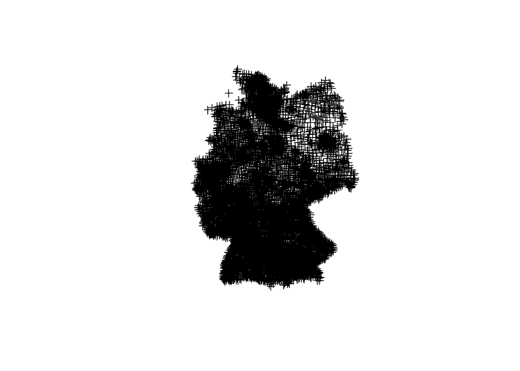

```r
# get centroid
postal_shape_centers <- SpatialPointsDataFrame(gCentroid(postal_shape, byid=TRUE),
                                      postal_shape@data, match.ID=FALSE)
# test, looks good
plot(postal_shape_centers)
```

```r
# transform to get meters
postal_shape_centers1<-spTransform(postal_shape_centers,CRS("+proj=utm +zone=32 +ellps=intl +towgs84=-87,-98,-121,0,0,0,0 +units=m +no_defs"))
proj4string(postal_shape_centers1)
```

[1] “+proj=utm +zone=32 +ellps=intl +units=m +no_defs”

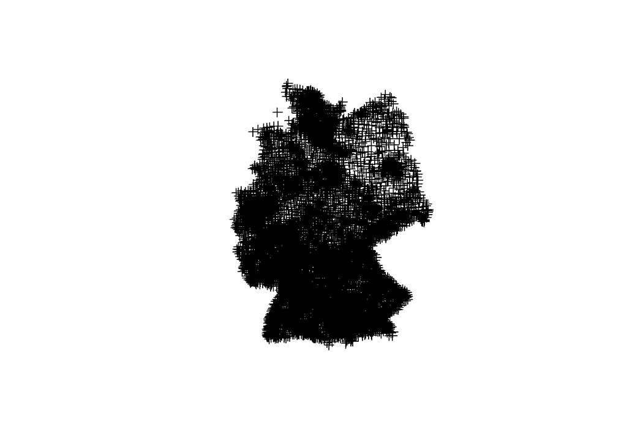

```r
plot(postal_shape_centers1)
```

```r
#########################################
# load vaccination centers with geo code
#########################################
# Source:
centers <- geojsonsf::geojson_sf("input/vaccination_centers/export.geojson")
# check if all covid 19 vaccinations
plyr::count(centers$vaccination)
```

```
    x freq
```

1 covid19 607

```r
# could be that vaccination center is multiple times in the data (see wiki page)
# for us not important, only minimal distance important
# extract the coordinnates
poly<-centers %>%
  dplyr::select(geometry)
class(poly)
```

[1] “sf” “data.frame”

```r
# calculate center again because some object are polgyon and we want points
centers  <- st_centroid(poly)
centers_points <- as_Spatial(centers)
# plot(centers_points)
# convert to same format
# transform to get meters
proj4string(centers_points)
```

[1] “+proj=longlat +datum=WGS84 +no_defs”

```r
pts <- spTransform(centers_points,CRS("+proj=utm +zone=32 +ellps=intl +towgs84=-87,-98,-121,0,0,0,0 +units=m +no_defs"))
proj4string(pts)
```

[1] “+proj=utm +zone=32 +ellps=intl +units=m +no_defs”

```r
#########################################
# merge
#########################################
# load shp as dataframe (to merge onto)
postal_shape_out <- st_read('input/postal code/plz-5stellig.shp/plz-5stellig.shp')
```

Reading layer `plz-5stellig' from data source`C:Vaccine Allocation\5_writingcode-5stellig.shp-5stellig.shp’ using driver `ESRI Shapefile’ Simple feature collection with 8169 features and 4 fields Geometry type: MULTIPOLYGON Dimension: XY Bounding box: xmin: 5.866315 ymin: 47.27011 xmax: 15.04181 ymax: 55.05868 Geodetic CRS: WGS 84

```r
# gDistance by default returns the cartesian minimum distance between the two geometries in the units of the current projection.
postal_shape_out$distance_vaccination<-sapply(1:length(postal_shape_centers1),function(x)gDistance(pts,postal_shape_centers1[x,]))
# check distribution, looks reasonable
# hist(postal_shape_out$distance_vaccination)

# rename to fit survey file
distance<-as.data.frame(postal_shape_out)%>%
  dplyr::rename(postcode = plz) %>%
  dplyr::mutate(postcode = as.numeric(postcode)) %>%
  dplyr::rename(city = note) %>%
  dplyr::mutate(distance_km=distance_vaccination/1000) %>%
  dplyr::select (-c(geometry,distance_vaccination))

typeof(distance$postcode)
```

[1] “double”

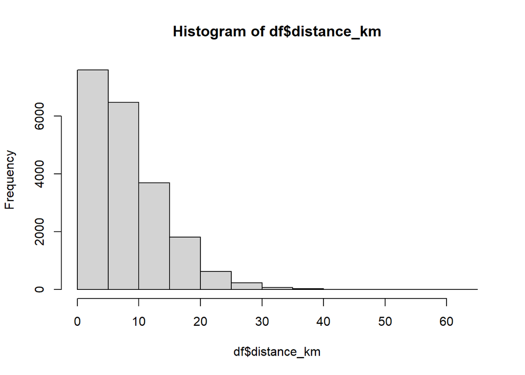

```r
# check for duplicates
n_occur <- data.frame(table(distance$postcode))

# merge
df <- left_join(df, distance, by = "postcode")
hist(df$distance_km)
```

```r
df <- df %>% dplyr::mutate(distance_km_raw = distance_km,
                           distance_km = (distance_km - min(distance_km, na.rm = TRUE))/
                             (max(distance_km, na.rm = TRUE) - min(distance_km, na.rm = TRUE)))
```

```r
#print(dfSummary(df[,covariate_names], graph.magnif = 0.75), method = 'render')
```

### Stacked dataframe

The wide dataframe is used for first differences analysis. In addition we make use of a stacked data frame for fixed effects analysis.

```r
# This should also be possible with pivot_longer
df_stacked <-
  bind_rows(mutate(df, t = 1), mutate(df, t = 2)) %>%
  mutate(
    outcome     = ifelse(t == 1, outcome_t1, outcome_t2),
    negative    = ifelse(t == 1, negative_t1, negative_t2),
    financialA  = ifelse(t == 1, financialA_t1, financialA_t2),
    financialB  = ifelse(t == 1, financialB_t1, financialB_t2),
    transaction = ifelse(t == 1, transaction_t1, transaction_t2),
    )
```

### Summary statistics

The next blocks calculate key summary statistics.

```r
# covariate_names[!(covariate_names %in% names(df))]

small_df <-
  df %>% dplyr::select(all_of(covariate_names)) %>%
  # select_if(is.numeric) %>%
  drop_na()
```

```r
# Make a data.frame containing summary statistics of interest

summ_stats <-
  small_df %>%
  fBasics::basicStats() %>%
  t() %>%
  as.data.frame() %>%
  dplyr::select("Mean", "Stdev", "Minimum", "1. Quartile", "Median",  "3. Quartile", "Maximum") %>%
  rename('Lower quartile'= '1. Quartile', 'Upper quartile' ='3. Quartile')

# Add in labels
summ_stats <- summ_stats %>%
  mutate(Variable = factor(rownames(summ_stats), var_list$new_name, var_list$label)) %>% relocate(Variable)
```

| Variable | Mean | Stdev | Minimum | Lower quartile | Median | Upper quartile | Maximum |
| --- | --- | --- | --- | --- | --- | --- | --- |
| Days since survey start | 0.57 | 0.19 | 0.05 | 0.38 | 0.57 | 0.71 | 1.00 |
| Male respondent | 0.50 | 0.50 | 0.00 | 0.00 | 0.00 | 1.00 | 1.00 |
| Age (percentile) | 0.49 | 0.27 | 0.00 | 0.26 | 0.51 | 0.72 | 1.00 |
| Non German Citizen | 0.03 | 0.16 | 0.00 | 0.00 | 0.00 | 0.00 | 1.00 |
| Born outside of Germany | 0.06 | 0.24 | 0.00 | 0.00 | 0.00 | 0.00 | 1.00 |
| Migration background of parents | 0.23 | 0.42 | 0.00 | 0.00 | 0.00 | 0.00 | 1.00 |
| In former East Germany | 0.15 | 0.36 | 0.00 | 0.00 | 0.00 | 0.00 | 1.00 |
| Household size 3 or more | 0.33 | 0.47 | 0.00 | 0.00 | 0.00 | 1.00 | 1.00 |
| Employed | 0.44 | 0.50 | 0.00 | 0.00 | 0.00 | 1.00 | 1.00 |
| Years of Education | 0.36 | 0.13 | 0.00 | 0.28 | 0.28 | 0.44 | 0.56 |
| Previously had Covid | 0.03 | 0.17 | 0.00 | 0.00 | 0.00 | 0.00 | 1.00 |
| Members of network infected | 0.40 | 0.36 | 0.00 | 0.00 | 0.50 | 0.50 | 1.00 |
| Good general health | 0.65 | 0.23 | 0.00 | 0.50 | 0.67 | 0.83 | 1.00 |
| Covid pre-existing conditions | 0.41 | 0.49 | 0.00 | 0.00 | 0.00 | 1.00 | 1.00 |
| Share of network vaccinated | 0.25 | 0.24 | 0.00 | 0.00 | 0.25 | 0.50 | 1.00 |
| Respondent has been vaccinated | 0.06 | 0.25 | 0.00 | 0.00 | 0.00 | 0.00 | 1.00 |
| Refusals | 0.16 | 0.37 | 0.00 | 0.00 | 0.00 | 0.00 | 1.00 |
| Undecided | 0.17 | 0.38 | 0.00 | 0.00 | 0.00 | 0.00 | 1.00 |
| Acceptant | 0.67 | 0.47 | 0.00 | 0.00 | 1.00 | 1.00 | 1.00 |
| Seeks Covid information | 0.73 | 0.32 | 0.00 | 0.50 | 0.75 | 1.00 | 1.00 |
| Believes media exaggerates risk | 0.42 | 0.32 | 0.00 | 0.25 | 0.50 | 0.75 | 1.00 |
| Compliance: mask rules | 0.90 | 0.16 | 0.00 | 0.80 | 1.00 | 1.00 | 1.00 |
| Compliance: distance rule | 0.82 | 0.19 | 0.00 | 0.80 | 0.80 | 1.00 | 1.00 |
| Support distancing even for vaccinated | 0.71 | 0.30 | 0.00 | 0.50 | 0.75 | 1.00 | 1.00 |
| Income loss due to Covid (.5 = no change) | 0.59 | 0.19 | 0.00 | 0.50 | 0.50 | 0.75 | 1.00 |
| Political interest | 0.65 | 0.29 | 0.00 | 0.33 | 0.67 | 1.00 | 1.00 |
| Voted last elections | 0.83 | 0.38 | 0.00 | 1.00 | 1.00 | 1.00 | 1.00 |
| Right leaning | 0.44 | 0.18 | 0.00 | 0.30 | 0.50 | 0.50 | 1.00 |
| AfD | 0.07 | 0.26 | 0.00 | 0.00 | 0.00 | 0.00 | 1.00 |
| Conservatives | 0.20 | 0.40 | 0.00 | 0.00 | 0.00 | 0.00 | 1.00 |
| Liberals | 0.05 | 0.23 | 0.00 | 0.00 | 0.00 | 0.00 | 1.00 |
| Green Party | 0.16 | 0.37 | 0.00 | 0.00 | 0.00 | 0.00 | 1.00 |
| Left Party | 0.08 | 0.26 | 0.00 | 0.00 | 0.00 | 0.00 | 1.00 |
| Social Democrats | 0.14 | 0.34 | 0.00 | 0.00 | 0.00 | 0.00 | 1.00 |
| No party identification | 0.27 | 0.44 | 0.00 | 0.00 | 0.00 | 1.00 | 1.00 |
| Willingness to take risks | 0.41 | 0.24 | 0.00 | 0.20 | 0.40 | 0.60 | 1.00 |
| General Trust | 0.41 | 0.25 | 0.00 | 0.20 | 0.40 | 0.60 | 1.00 |
| Trust state government | 0.44 | 0.29 | 0.00 | 0.25 | 0.50 | 0.75 | 1.00 |
| Trust experts | 0.64 | 0.26 | 0.00 | 0.50 | 0.75 | 0.75 | 1.00 |
| Trust federal government | 0.45 | 0.27 | 0.00 | 0.25 | 0.50 | 0.75 | 1.00 |
| Trust media | 0.38 | 0.25 | 0.00 | 0.25 | 0.50 | 0.50 | 1.00 |
| Trust healthcare | 0.57 | 0.26 | 0.00 | 0.50 | 0.50 | 0.75 | 1.00 |
| Values social solidarity | 0.58 | 0.23 | 0.00 | 0.50 | 0.50 | 0.70 | 1.00 |
| Values international solidarity | 0.58 | 0.31 | 0.00 | 0.40 | 0.50 | 0.80 | 1.00 |
| EU support | 0.52 | 0.29 | 0.00 | 0.30 | 0.50 | 0.70 | 1.00 |
| Migration support | 0.48 | 0.27 | 0.00 | 0.30 | 0.50 | 0.70 | 1.00 |
| Distance to Vaccination Center | 0.13 | 0.10 | 0.00 | 0.06 | 0.11 | 0.18 | 1.00 |

Pairwise correlations.

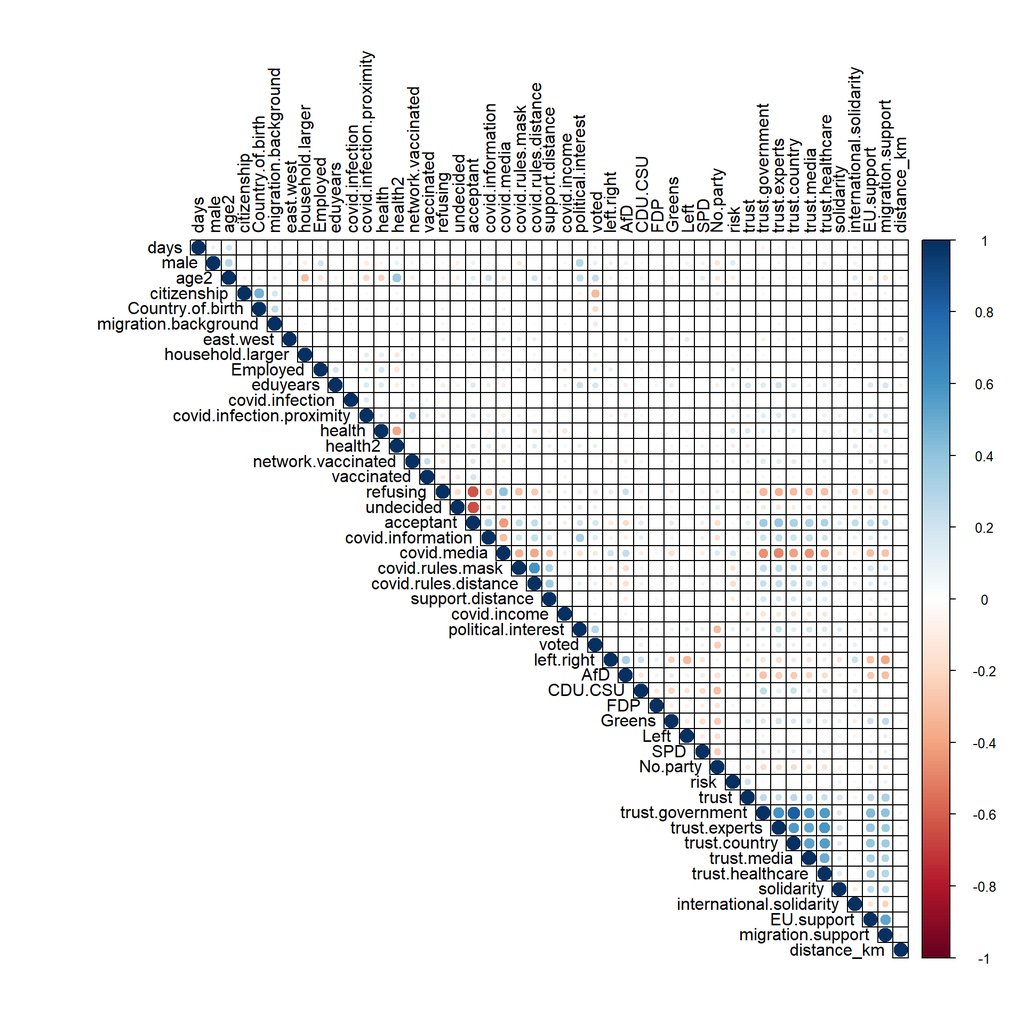

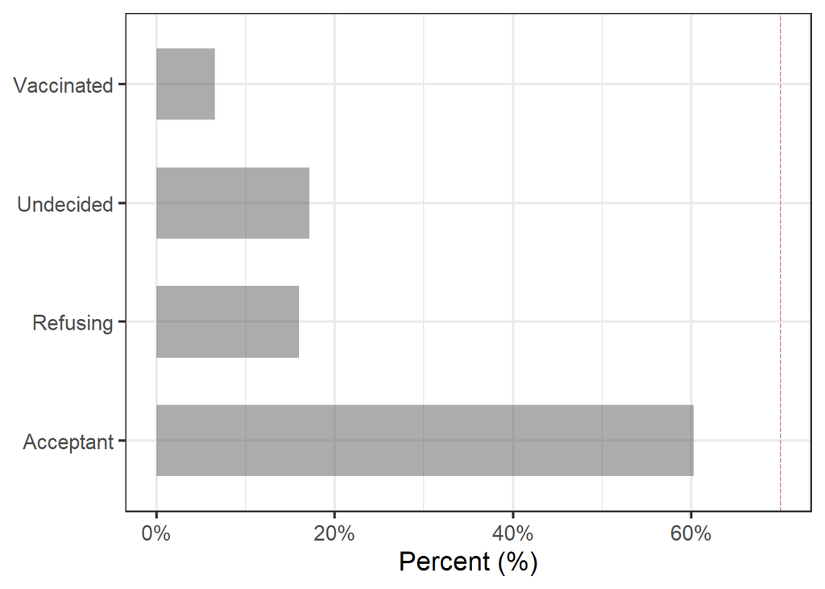

```r
fig_1 <- df %>% ggplot(aes(status)) +
  geom_hline(yintercept=0.7, linetype="longdash", lwd=0.35, size=0.75, colour = "#B55555") +
  geom_bar(aes(y = (..count..)/sum(..count..)),width = 0.6,alpha = 0.5) +
  scale_y_continuous(labels=scales::percent) +
  theme_bw(base_size=16)+
  theme(axis.title.y = element_blank())+
  ylab("Percent (%)")+
  coord_flip()
fig_1
```

```r
pdf(fig_1_path, height = 3, width = 6)
fig_1
dev.off()
```

Concerns of the hesitent and undecided

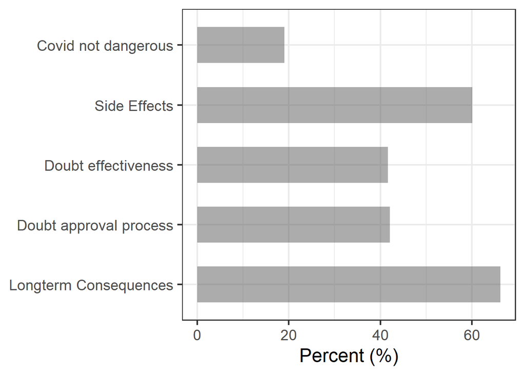

```r
fig_11 <-
  df %>% dplyr::select(starts_with("fear.")) %>%
  mutate_if(is.character, as.numeric) %>%
  melt(variable.name = "Group") %>%
  mutate(Group =
           factor(Group,
                  c("fear.longterm", "fear.admission", "fear.effectiveness", "fear.side.effects", "fear.no.danger"),
                  c("Longterm Consequences", "Doubt approval process", "Doubt effectiveness", "Side Effects", "Covid not dangerous")))%>%
  group_by(Group) %>%
  summarize(mean = 100*mean(value, na.rm = TRUE))  %>%
  ggplot() +
  geom_bar(aes(Group, mean), stat = "identity", width = 0.6,alpha = 0.5)+
  theme_bw(base_size=18)+
  ylab("Percent (%)")+
  theme(axis.title.y = element_blank())+
  coord_flip()
 fig_11
```

```r
pdf(fig_11_path, height = 4, width = 8)
fig_11
dev.off()
```

### Correlates of Hesitancy

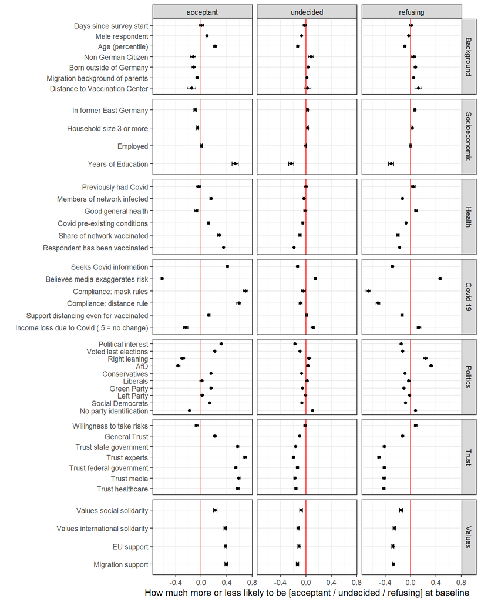

```r
family_order <- var_list %>% group_by(family) %>% slice(1) %>% arrange(Family_order) %>% pull(family)

correlates <-
list("acceptant", "refusing", "undecided") %>%
lapply(function(y)
  lapply(setdiff(covariate_names, tolower(statuses)), function(x)
lm_robust(as.formula(paste(y, "~", x)), data = df) %>% tidy %>% dplyr::mutate(y=y, x=x)) %>% bind_rows) %>% bind_rows %>% dplyr::filter(term!="(Intercept)" & !(x %in% c("acceptant", "refusing", "undecided"))) %>%
  dplyr::mutate(x = factor(x, rev(var_list$new_name), rev(var_list$label))) %>%
  left_join(var_list %>% dplyr::rename(term = new_name) %>% dplyr::select(term, family)) %>%
  dplyr::mutate(family = factor(family, family_order))


fig_cov <-
  correlates %>%
dplyr::mutate(y = factor(y, c("acceptant", "undecided", "refusing" ))) %>%
dplyr::filter(x!="federal.state") %>%
ggplot(aes(estimate    , x)) + geom_point() + facet_grid(family ~ y, scales = "free_y") + ylab("") + xlab("How much more or less likely to be [acceptant / undecided / refusing] at baseline")  +
  geom_vline(xintercept = 0, color = "red") +
  theme_bw() +
  geom_errorbar(aes(xmin = conf.low, xmax = conf.high), width = .25)

fig_cov
```

```r
pdf(correlates_plot_path, height =9, width = 8)
fig_cov
dev.off()
```

## Main Results

### Background

| Factor $Z$ | Level $L$ |
| --- | --- |
| Negative incentives | Control: There are **no special regulations** for vaccinated people even when the Corona incidence is high. For example, they cannot travel again, visit cinemas, restaurants or concerts and are still … |
|  | Treatment: **Special regulations** apply to vaccinated people. For example, even when the Corona incidence is high, they can travel again, visit cinemas, restaurants or concerts and are not subject to… |
| Reduction Transaction Cost | Control: Eligible citizens can get vaccinated against Corona at the nearest vaccination center, but not from their family doctor. |
|  | Treatment: Eligible citizens can have themselves vaccinated against Corona at the nearest vaccination center or their family doctor. |
| Financial renumeration | Control: Citizens who are vaccinated will not receive any allowance after receiving the vaccination. |
|  | Treatment: Citizens who get vaccinated receive an expense allowance of {Level: 25} euros after receiving the vaccination. |
|  | Treatment: Citizens who get vaccinated receive an expense allowance of {Level: 50} euros after receiving the vaccination. |

### Check strategy

We demonstrate that first differences and fixed effects effects analyses produce essentially identical results.

```r
# Analysis

lm_robust(
  outcome_diff ~ negative_diff + financialA_diff + financialB_diff + transaction_diff,
  data=df, se_type = "stata") %>%
  tidy %>%
  kable(caption = "Basic first differences analysis", digits = 2, booktabs = TRUE)
```

Basic first differences analysis

| term | estimate | std.error | statistic | p.value | conf.low | conf.high | df | outcome |
| --- | --- | --- | --- | --- | --- | --- | --- | --- |
| (Intercept) | 0.00 | 0 | -3.43 | 0 | -0.01 | 0.00 | 20495 | outcome_diff |
| negative_diff | 0.03 | 0 | 15.52 | 0 | 0.02 | 0.03 | 20495 | outcome_diff |
| financialA_diff | 0.01 | 0 | 5.40 | 0 | 0.01 | 0.01 | 20495 | outcome_diff |
| financialB_diff | 0.02 | 0 | 11.30 | 0 | 0.02 | 0.03 | 20495 | outcome_diff |
| transaction_diff | 0.03 | 0 | 17.99 | 0 | 0.03 | 0.03 | 20495 | outcome_diff |

```r
lm_robust(
  outcome ~ negative + financialA + financialB + transaction,
  data=df_stacked, se_type = "stata", fixed_effects =  ~ID) %>%
  tidy %>%
  kable(caption = "Basic Fixed effects analysis", digits = 3, booktabs = TRUE)
```

Basic Fixed effects analysis

| term | estimate | std.error | statistic | p.value | conf.low | conf.high | df | outcome |
| --- | --- | --- | --- | --- | --- | --- | --- | --- |
| negative | 0.025 | 0.002 | 15.500 | 0 | 0.022 | 0.028 | 20496 | outcome |
| financialA | 0.010 | 0.002 | 5.441 | 0 | 0.006 | 0.013 | 20496 | outcome |
| financialB | 0.022 | 0.002 | 11.257 | 0 | 0.018 | 0.026 | 20496 | outcome |
| transaction | 0.030 | 0.002 | 18.113 | 0 | 0.027 | 0.033 | 20496 | outcome |

```r
# The analysis function takes a dataframe, demeans within the (differenced) Xs
our_analysis <- function(dff)
  lm_robust(
  outcome_diff ~ negative*financialA*transaction + negative*financialB*transaction,
  data = dff %>%
    mutate(negative = negative_diff - mean(negative_diff),
           financialA = financialA_diff- mean(financialA_diff),
           financialB = financialB_diff - mean(financialB_diff),
           transaction = transaction_diff - mean(transaction_diff)),
  se_type = "stata")


our_analysis(df) %>% tidy %>%
  kable(caption = "Basic Fixed effects analysis with interactions", digits = 3)
```

Basic Fixed effects analysis with interactions

| term | estimate | std.error | statistic | p.value | conf.low | conf.high | df | outcome |
| --- | --- | --- | --- | --- | --- | --- | --- | --- |
| (Intercept) | -0.004 | 0.001 | -3.752 | 0.000 | -0.006 | -0.002 | 20488 | outcome_diff |
| negative | 0.025 | 0.002 | 15.214 | 0.000 | 0.022 | 0.028 | 20488 | outcome_diff |
| financialA | 0.010 | 0.002 | 5.343 | 0.000 | 0.006 | 0.013 | 20488 | outcome_diff |
| transaction | 0.030 | 0.002 | 18.078 | 0.000 | 0.026 | 0.033 | 20488 | outcome_diff |
| financialB | 0.022 | 0.002 | 11.236 | 0.000 | 0.018 | 0.026 | 20488 | outcome_diff |
| negative:financialA | 0.006 | 0.003 | 2.092 | 0.036 | 0.000 | 0.012 | 20488 | outcome_diff |
| negative:transaction | 0.002 | 0.003 | 0.734 | 0.463 | -0.003 | 0.007 | 20488 | outcome_diff |
| financialA:transaction | -0.001 | 0.003 | -0.385 | 0.700 | -0.006 | 0.004 | 20488 | outcome_diff |
| negative:financialB | 0.006 | 0.003 | 1.820 | 0.069 | 0.000 | 0.012 | 20488 | outcome_diff |
| transaction:financialB | -0.002 | 0.003 | -0.595 | 0.552 | -0.007 | 0.004 | 20488 | outcome_diff |
| negative:financialA:transaction | -0.003 | 0.004 | -0.609 | 0.542 | -0.011 | 0.006 | 20488 | outcome_diff |
| negative:transaction:financialB | -0.006 | 0.005 | -1.294 | 0.196 | -0.015 | 0.003 | 20488 | outcome_diff |

### Main analysis

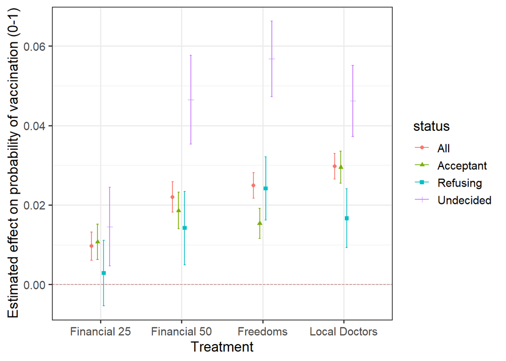

```r
statuses <- unique(df$status)

model_list <- lapply(statuses, function(j) our_analysis(df %>% dplyr::filter(status == j)))
names(model_list) <- statuses
model_list$All <- our_analysis(df)

by_status <-
  lapply(model_list, function(model) tidy(model)) %>%
  bind_rows(.id = "status") %>%
  mutate(status = factor(status, c("All", statuses)))

# Table version

fileConn <- file(tab_2_path)
writeLines(texreg(model_list, float.pos = "h!", include.ci = FALSE, caption = "Main results, with interactions. Individual fixed effects modelled by regressing differences in responses across two vignetters on differences in treatments and interactions. All treatments are centered on zero for each group.",
                  custom.coef.map =  list("(Intercept)" = "Constant (No incentives)",
                                          "financialA" = "25 Euro incentive",
                                          "financialB" = "50 Euro incentive",
                                          "negative" = "Freedoms",
                                          "transaction" = "Local doctors",

"negative:financialA" = "Freedoms * 25 Euros",
"negative:financialB" = "Freedoms * 50 Euros",
"negative:transaction" = "Freedoms * Local doctors",
"financialA:transaction" = "Local doctors * 25 Euros",
"transaction:financialB" = "Local doctors * 50 Euros",
"negative:financialA:transaction" = "Freedoms * Local doctors * 25 Euros",
"negative:transaction:financialB" ="Freedoms * Local doctors * 50 Euros"), digits = 3), fileConn)
close(fileConn)


# Figure Version
figure_1A <-

  by_status %>%
  dplyr::filter(term %in% c("negative", "financialA", "financialB", "transaction")) %>%
  dplyr::filter(status != "Vaccinated") %>%
  mutate(Treatment = factor(term, treatment_levels, treatment_labels)) %>%

  ggplot(aes(Treatment, estimate, color = status, shape = status)) +
  geom_point(position = position_dodge(width = 0.3)) +
  geom_errorbar(aes(ymin = conf.low, ymax = conf.high), position = position_dodge(width = 0.3), width = .1)+
  geom_hline(yintercept=0, linetype="longdash", lwd=0.35, size=0.75, colour = "#B55555") +
  theme_bw(base_size=14)+
  ylab("Estimated effect on probability of vaccination (0-1)")

figure_1A
```

#### Additional vaccinated subgroup

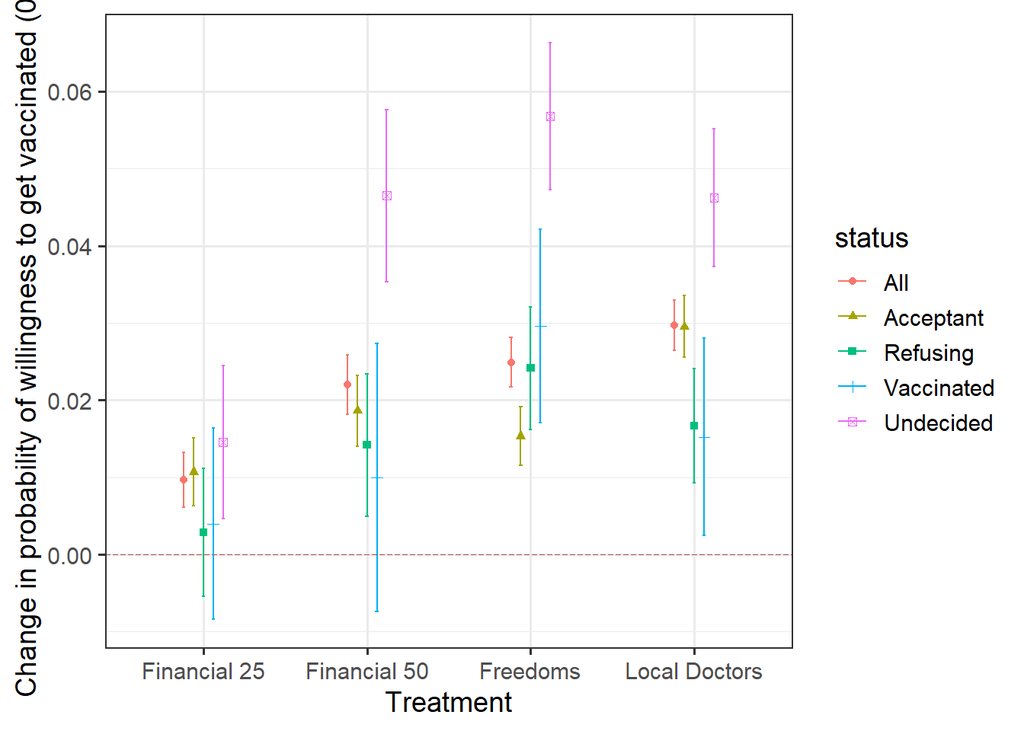

```r
# Figure Version
figure_subgroups <-

  by_status %>%
  dplyr::filter(term %in% c("negative", "financialA", "financialB", "transaction")) %>%
  #dplyr::filter(status != "Vaccinated") %>%
  mutate(Treatment = factor(term, treatment_levels, treatment_labels)) %>%

  ggplot(aes(Treatment, estimate, color = status, shape = status)) +
  geom_point(position = position_dodge(width = 0.3)) +
  geom_errorbar(aes(ymin = conf.low, ymax = conf.high), position = position_dodge(width = 0.3), width = .1)+
  geom_hline(yintercept=0, linetype="longdash", lwd=0.35, size=0.75, colour = "#B55555") +
  theme_bw(base_size=14)+
  ylab("Change in probability of willingness to get vaccinated (0-1)")

figure_subgroups
```

#### By round

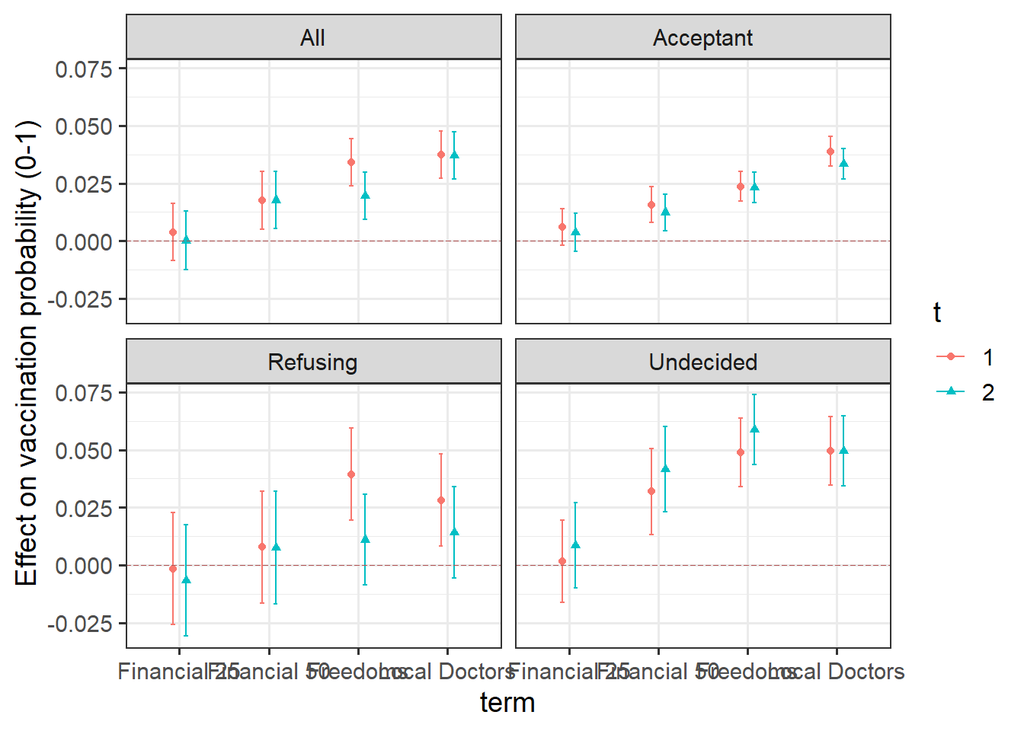

```r
# analysis by period
df_stacked2 <- bind_rows(
  df_stacked %>% dplyr::filter(status != "Vaccinated"),
  df_stacked %>% dplyr::filter(status != "Vaccinated") %>% mutate(status = "All"))

out <-   lapply(1:2, function(period)
              df_stacked2 %>% dplyr::filter(t==period) %>%
                split(.$status) %>%
                map(~lm_robust(outcome ~ negative + financialA + financialB + transaction, data = .)) %>%
                map(tidy) %>%
  bind_rows(.id = "status") %>% mutate(t=period)) %>%
  bind_rows() %>%
  dplyr::filter(term %in% treatments) %>%
  dplyr::filter(status != "Vaccinated") %>%
  mutate(t = factor(t)) %>%
  mutate(status = factor(status, c("All", "Acceptant", "Refusing", "Undecided"))) %>%
  mutate(term = factor(term, treatments, treatment_labels))

out %>%
  ggplot(aes(term, estimate, color = t, shape = t)) +
  geom_point(position = position_dodge(width = 0.3)) +
  geom_errorbar(aes(ymin = conf.low, ymax = conf.high), position = position_dodge(width = 0.3), width = .1) +
  geom_hline(yintercept=0, linetype="longdash", lwd=0.35, size=0.75, colour = "#B55555") +
  theme_bw(base_size=14)+ facet_wrap(~status, ncol = 2) +
  ylab("Effect on vaccination probability (0-1)")
```

```r
# Analysis first round
  first <-
  df %>%
  split(.$status) %>%
  map(~lm_robust(outcome_t1 ~ negative_t1 + financialA_t1 + financialB_t1 + transaction_t1, data = .)) %>%
  map(tidy) %>%
  bind_rows(.id = "status")%>%
  dplyr::filter(term %in% c("negative_t1", "financialA_t1", "financialB_t1", "transaction_t1")) %>%
  dplyr::filter(status != "Vaccinated")

  first<-first %>%
  ggplot(aes(term, estimate, color = status, shape = status)) +
  geom_point(position = position_dodge(width = 0.3)) +
  geom_errorbar(aes(ymin = conf.low, ymax = conf.high), position = position_dodge(width = 0.3), width = .1)+
  geom_hline(yintercept=0, linetype="longdash", lwd=0.35, size=0.75, colour = "#B55555") +
  theme_bw(base_size=14)+
  ylab("Change in probability of willingness to get vaccinated (0-1)")+
  ggtitle("First Vignette")

# Analysis second round
  second<-df %>%
  split(.$status) %>%
  map(~lm_robust(outcome_t2~ negative_t2 + financialA_t2 + financialB_t2 + transaction_t2, data = .)) %>%
  map(tidy) %>%
  bind_rows(.id = "status")%>%
  dplyr::filter(term %in% c("negative_t2", "financialA_t2", "financialB_t2", "transaction_t2")) %>%
  dplyr::filter(status != "Vaccinated") %>%
  ggplot(aes(term, estimate, color = status, shape = status)) +
  geom_point(position = position_dodge(width = 0.3)) +
  geom_errorbar(aes(ymin = conf.low, ymax = conf.high), position = position_dodge(width = 0.3), width = .1)+
  geom_hline(yintercept=0, linetype="longdash", lwd=0.35, size=0.75, colour = "#B55555") +
  theme_bw(base_size=14)+
  ylab("Change in probability of willingness to get vaccinated (0-1)")+
  ggtitle("Second Vignette")

# Analysis first round
  ggarrange(first, second)
```

[output not shown]

### Consistency bias

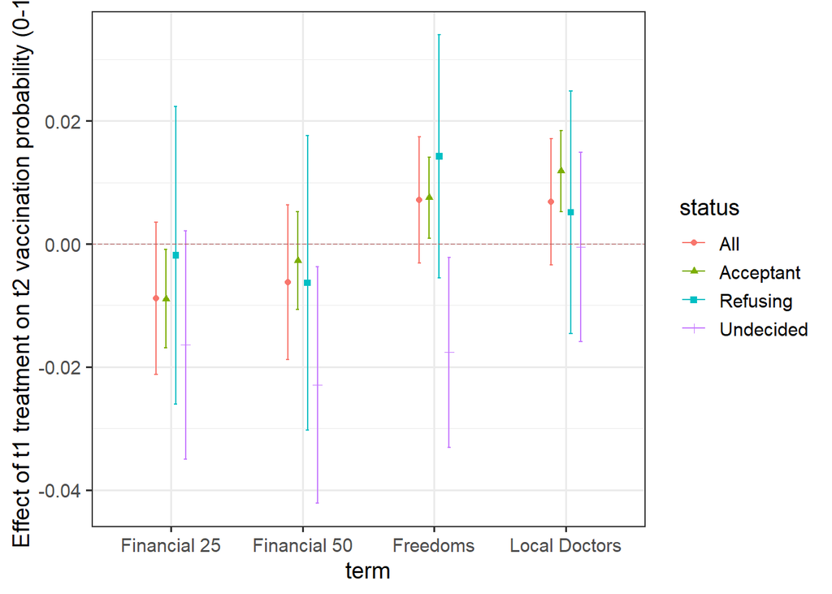

```r
# effect of lag:
# Note that lag treatment is negatively correlated with current treatment

lag_out <-
  bind_rows(
    df %>% dplyr::filter(status != "Vaccinated"),
    df %>% dplyr::filter(status != "Vaccinated") %>% mutate(status = "All"))  %>%
                split(.$status) %>%
                map(~lm_robust(outcome_t2 ~ negative_t1 + financialA_t1 + financialB_t1 + transaction_t1, data = .)) %>%
                map(tidy) %>%
  bind_rows(.id = "status") %>%
  dplyr::filter(term %in% paste0(treatments, "_t1")) %>%
  dplyr::filter(status != "Vaccinated") %>%
  mutate(status = factor(status, c("All", "Acceptant", "Refusing", "Undecided"))) %>%
  mutate(term = factor(term, paste0(treatments, "_t1"), treatment_labels))

lag_out %>%
  ggplot(aes(term, estimate, color = status, shape = status)) +
  geom_point(position = position_dodge(width = 0.3)) +
  geom_errorbar(aes(ymin = conf.low, ymax = conf.high), position = position_dodge(width = 0.3), width = .1) +
  geom_hline(yintercept=0, linetype="longdash", lwd=0.35, size=0.75, colour = "#B55555") +
  theme_bw(base_size=14)+
  ylab("Effect of t1 treatment on t2 vaccination probability (0-1)")
```

```r
c(
  cor(df$financialA_t1, df$financialA_t2),
  cor(df$financialB_t1, df$financialB_t2),
  cor(df$negative_t1, df$negative_t2),
  cor(df$transaction_t1, df$transaction_t2))
```

```
[1] -0.12590611 -0.07113368 -0.13421823 -0.06858775
```

Accounting for current:

```r
lm_robust(outcome_t2 ~
            negative_t1 + financialA_t1 + financialB_t1 + transaction_t1 +
                                 financialA_t2*transaction_t2*negative_t2+
                                 financialB_t2*transaction_t2*negative_t2,
          data = df %>% dplyr::filter(status != "Vaccinated")) %>% tidy %>%
  kable(digits = 2)
```

| term | estimate | std.error | statistic | p.value | conf.low | conf.high | df | outcome |
| --- | --- | --- | --- | --- | --- | --- | --- | --- |
| (Intercept) | 0.66 | 0.01 | 60.95 | 0.00 | 0.64 | 0.68 | 19140 | outcome_t2 |
| negative_t1 | 0.01 | 0.01 | 1.64 | 0.10 | 0.00 | 0.02 | 19140 | outcome_t2 |
| financialA_t1 | -0.01 | 0.01 | -1.46 | 0.14 | -0.02 | 0.00 | 19140 | outcome_t2 |
| financialB_t1 | -0.01 | 0.01 | -0.95 | 0.34 | -0.02 | 0.01 | 19140 | outcome_t2 |
| transaction_t1 | 0.01 | 0.01 | 1.80 | 0.07 | 0.00 | 0.02 | 19140 | outcome_t2 |
| financialA_t2 | 0.00 | 0.01 | 0.22 | 0.83 | -0.02 | 0.03 | 19140 | outcome_t2 |
| transaction_t2 | 0.05 | 0.01 | 3.75 | 0.00 | 0.02 | 0.07 | 19140 | outcome_t2 |
| negative_t2 | 0.02 | 0.01 | 1.53 | 0.13 | -0.01 | 0.04 | 19140 | outcome_t2 |
| financialB_t2 | 0.02 | 0.01 | 1.92 | 0.06 | 0.00 | 0.05 | 19140 | outcome_t2 |
| financialA_t2:transaction_t2 | -0.02 | 0.02 | -0.96 | 0.34 | -0.05 | 0.02 | 19140 | outcome_t2 |
| financialA_t2:negative_t2 | 0.01 | 0.02 | 0.42 | 0.67 | -0.03 | 0.04 | 19140 | outcome_t2 |
| transaction_t2:negative_t2 | 0.00 | 0.02 | 0.21 | 0.83 | -0.03 | 0.04 | 19140 | outcome_t2 |
| transaction_t2:financialB_t2 | -0.01 | 0.02 | -0.40 | 0.69 | -0.04 | 0.03 | 19140 | outcome_t2 |
| negative_t2:financialB_t2 | 0.00 | 0.02 | 0.04 | 0.97 | -0.03 | 0.04 | 19140 | outcome_t2 |
| financialA_t2:transaction_t2:negative_t2 | 0.00 | 0.03 | -0.03 | 0.98 | -0.05 | 0.05 | 19140 | outcome_t2 |
| transaction_t2:negative_t2:financialB_t2 | -0.02 | 0.03 | -0.87 | 0.38 | -0.07 | 0.03 | 19140 | outcome_t2 |

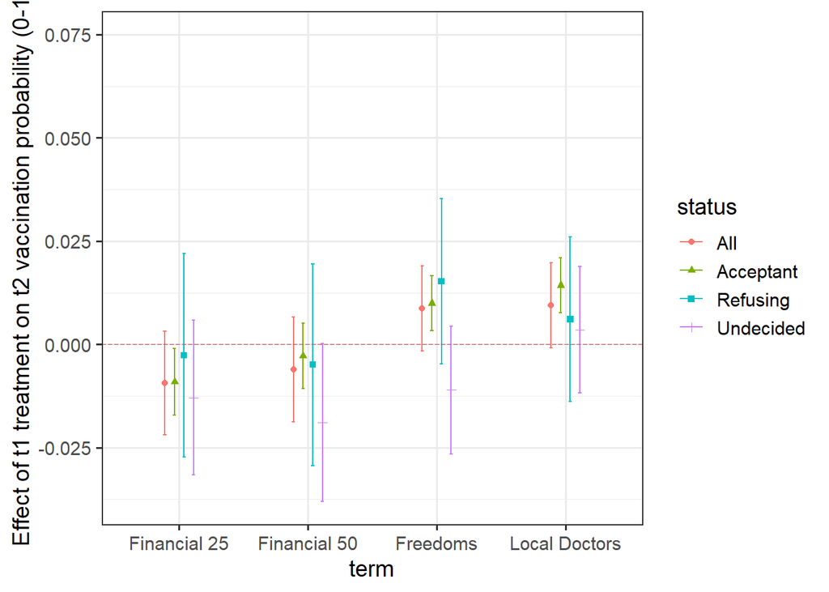

```r
lag_out_2 <-
  bind_rows(
    df %>% dplyr::filter(status != "Vaccinated"),
    df %>% dplyr::filter(status != "Vaccinated") %>% mutate(status = "All"))  %>%
                split(.$status) %>%
                map(~lm_robust(outcome_t2 ~ negative_t1 + financialA_t1 + financialB_t1 + transaction_t1 +
                                 financialA_t2*transaction_t2*negative_t2+
                                 financialB_t2*transaction_t2*negative_t2, data = .)) %>%
                map(tidy) %>%
  bind_rows(.id = "status") %>%
  dplyr::filter(term %in% paste0(treatments, "_t1")) %>%
  dplyr::filter(status != "Vaccinated") %>%
  mutate(status = factor(status, c("All", "Acceptant", "Refusing", "Undecided"))) %>%
  mutate(term = factor(term, paste0(treatments, "_t1"), treatment_labels))

lag_out_2 %>%
  ggplot(aes(term, estimate, color = status, shape = status)) +
  geom_point(position = position_dodge(width = 0.3)) +
  geom_errorbar(aes(ymin = conf.low, ymax = conf.high), position = position_dodge(width = 0.3), width = .1) +
  geom_hline(yintercept=0, linetype="longdash", lwd=0.35, size=0.75, colour = "#B55555") +
  theme_bw(base_size=14)+
  ylab("Effect of t1 treatment on t2 vaccination probability (0-1)")  + ylim(c(NA, .075))
```

Check for change in levels. DId aerage acceptance go up between measurements?

```r
lm_robust(outcome_diff ~ 1, data = df) %>% tidy %>% kable(digits = 2)
```

| term | estimate | std.error | statistic | p.value | conf.low | conf.high | df | outcome |
| --- | --- | --- | --- | --- | --- | --- | --- | --- |
| (Intercept) | 0 | 0 | -3.61 | 0 | -0.01 | 0 | 20499 | outcome_diff |

### Omnibus treatment

Note that no fixed effects used here since we generally have only one observation per person.

```r
data_omnibus <- lapply(statuses, function(s)
  df_stacked %>%
      mutate(
        omnibus = negative * financialB * transaction,
        zip = (1-negative) * (1-financialA) * (1-financialB) * (1-transaction)) %>%
      dplyr::filter((omnibus==1) | (zip==1)) %>%
      dplyr::filter(status == s))

names(data_omnibus) <- statuses

lapply(data_omnibus, function(d)
table(table(d$ID))) %>% bind_cols %>% mutate(freq = 1:2) %>% relocate(freq) %>%
  kable(caption = "Most subjects appear only once", booktabs = TRUE)
```

Most subjects appear only once

| freq | Acceptant | Refusing | Vaccinated | Undecided |
| --- | --- | --- | --- | --- |
| 1 | 3772 | 983 | 422 | 1105 |
| 2 | 154 | 49 | 21 | 43 |

```r
omnibus <- lapply(data_omnibus, function(d) lm_robust(outcome ~ omnibus, data = d, cluster = ID, se_type = "stata"))

  omnibus[[4]] %>% tidy %>%
  kable(digits = 2, caption = "All or nothing comparisons", booktabs = TRUE)
```

All or nothing comparisons

| term | estimate | std.error | statistic | p.value | conf.low | conf.high | df | outcome |
| --- | --- | --- | --- | --- | --- | --- | --- | --- |
| (Intercept) | 0.40 | 0.01 | 43.83 | 0 | 0.38 | 0.41 | 1147 | outcome |
| omnibus | 0.13 | 0.01 | 10.23 | 0 | 0.11 | 0.16 | 1147 | outcome |

```r
fileConn<-file(tab_3_path)
writeLines(texreg(omnibus, float.pos = "h!", include.ci = FALSE, caption = "\\label{omnibus} Effects of receiving all treatments compared to all control conditions", custom.coef.map =  list("(Intercept)" = "Constant (No incentives)","omnibus"
= "Maximal incentives")), fileConn)
close(fileConn)
```

### Aggregate effects

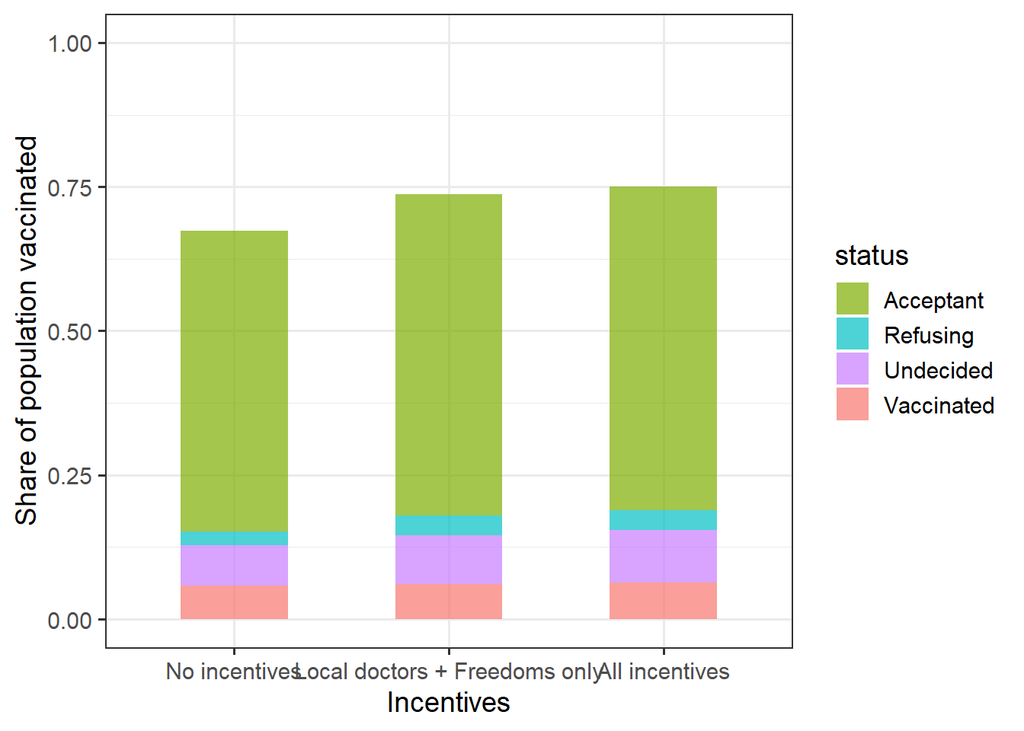

```r
policy_experiments <- list(
  experiment_1 =
    df_stacked %>%
      mutate(
        Z = negative * financialB * transaction,
        zip = (1-negative) * (1-financialA) * (1-financialB) * (1-transaction)) %>%
      dplyr::filter((Z==1) | (zip==1)) %>%
  group_by(Z) %>%
  mutate(N = n()) %>% ungroup() %>%
  group_by(status, Z) %>%
  summarize(n = n()/mean(N), share_pop_vaccinated = n()*mean(outcome)/mean(N)),

  experiment_2 =
    df_stacked %>%
      dplyr::filter(financialA==0 & negative ==1 & transaction ==1) %>%
  group_by(financialB) %>%
  mutate(N = n()) %>% ungroup() %>%
  group_by(status, financialB) %>%
  summarize(n = n()/mean(N), share_pop_vaccinated = n()*mean(outcome)/mean(N)) %>% arrange(financialB) %>% mutate(Z = financialB)) %>% bind_rows(.id = "experiment") %>%


  mutate(
  Z =
  (experiment == "experiment_1") *  Z +
  (experiment == "experiment_2") *  (Z + .5),
  Z = factor(Z, c(0, .5, 1), c("No incentives", "Local doctors + Freedoms only", "All incentives")))  %>%
  dplyr::filter(!is.na(Z))

# set coolors to be consistent
group.colors <- c(Acceptant = "#7CAE00", Refusing = "#00BFC4", Undecided ="#C77CFF", Vaccinated = "#F8766D")

figure_1B <- policy_experiments %>%
  ggplot(aes(fill=status, y=share_pop_vaccinated, x=Z)) +
  geom_bar(position="stack", stat="identity",width = 0.5,alpha = 0.7) +
  scale_fill_manual(values=group.colors)+
  ylab("Share of population vaccinated") +
  theme_bw(base_size=14)+
  ylim(0:1) +
  xlab("Incentives")

figure_1B
```

```r
policy_experiments %>% group_by(Z) %>% arrange(status) %>% mutate(cumul = cumsum(share_pop_vaccinated)) %>% slice(n())
```

```
# A tibble: 3 x 7
# Groups:   Z [3]
  experiment  status   Z                    n share_pop_vaccin~ financialB cumul
  <chr>       <chr>    <fct>            <dbl>             <dbl>      <dbl> <dbl>
1 experiment~ Vaccina~ No incentives   0.0674            0.0582         NA 0.674
2 experiment~ Vaccina~ Local doctors ~ 0.0678            0.0606          0 0.738
3 experiment~ Vaccina~ All incentives  0.0687            0.0636         NA 0.750
```

### Export Fig 1

Fig 1 in the paper has two panels. Exported here.

```r
fig_1_AB <- ggarrange(figure_1A, figure_1B,
                    labels = c("A", "B"),
                    ncol = 1, nrow = 2)

pdf(fig_1_AB_path, width = 8, height = 12)
fig_1_AB
dev.off()
```

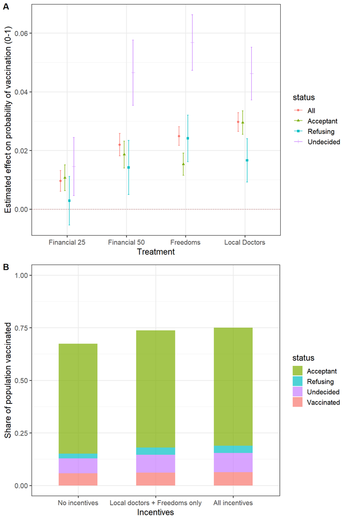

```r
fig_1_AB
```

### Notes

Share of hesitant, undecided, that are AFD supports or support no party

```r
df %>%
  group_by(status) %>%
  summarize(AfD = mean(AfD),
            no_party = mean(No.party),
            trust_experts = mean(trust.experts),
            media_exaggerates = mean(covid.media),
            fear_longterm = mean(fear.longterm, na.rm = TRUE)) %>%
  kable(digits = 2, booktabs = TRUE)
```

| status | AfD | no_party | trust_experts | media_exaggerates | fear_longterm |
| --- | --- | --- | --- | --- | --- |
| Acceptant | 0.03 | 0.21 | 0.71 | 0.33 | NaN |
| Refusing | 0.20 | 0.37 | 0.42 | 0.72 | 0.64 |
| Undecided | 0.08 | 0.39 | 0.56 | 0.51 | 0.68 |
| Vaccinated | 0.04 | 0.24 | 0.68 | 0.38 | NaN |

## Heterogeneity

### Background

For heterogeneity analysis we drawon the Causal Forests approach described in [Athey, Tibshrani and Wager (Annals of Statistics, 2019)](https://projecteuclid.org/download/pdfview_1/euclid.aos/1547197251) , [Nie and Wager, 2017](https://arxiv.org/abs/1712.04912)

### Helpers

A function to prep het effects data for a given treatment, removing others.

```r
num_tiles <- 4  # ntiles = CATE is above / below the median

# Note this is set up so that we can swap in the difference outcome easily

het_df <- function(treatment_name = "transaction_diff",
                   outcome_name = "outcome_diff",
                   data = df) {
  data$W = data[treatment_name][[1]]
  data$Y = data[outcome_name][[1]]
  data %>%
    dplyr::select(Y, W, ID, all_of(covariate_names)) %>%
    drop_na() %>%
    mutate_if(is.factor, as.numeric)  %>%
    # mutate(federal.state =  as.numeric(factor(federal.state))) %>%
    # Trick to render W binary
    dplyr::mutate(
      Y = ifelse(W<0, -Y, Y),
      W = W^2)
}
```

```r
# heterogeneous treatment effects

#### Function to fit the forest and save outputs: input dataframe should have a privileged Y and W

f_cf <- function(df, n_trees = 1000) {

  # rule of thumb: num.trees = number of individuals

  df_train <- sample_frac(df, replace=FALSE, size=train_fraction)
  df_test  <- anti_join(df, df_train, by = "ID") #need to check on larger
  X <- as.matrix(df_train[, covariate_names])

  cf <-
    causal_forest(
    X = X,
    Y = df_train$Y,
    W = df_train$W,
    num.trees=n_trees)

  #### Predict point estimates and standard errors (training set, out-of-bag)
  oob_pred      <- predict(cf, estimate.variance=TRUE)
  oob_tauhat_cf <- oob_pred$predictions
  oob_tauhat_cf_se <- sqrt(oob_pred$variance.estimates)

  #### Predict point estimates and standard errors (test set)
  # test_pred <- predict(cf, newdata=as.matrix(df_test[covariate_names]), estimate.variance=TRUE)
  # tauhat_cf_test <- test_pred$predictions
  # tauhat_cf_test_se <- sqrt(test_pred$variance.estimates)

  var_imp        <- c(variable_importance(cf))
  names(var_imp) <- covariate_names
  var_imp <- var_imp %>% sort(decreasing=TRUE)

  df_train$cate  <- oob_tauhat_cf
  df_train$ntile <- factor(ntile(oob_tauhat_cf, n=num_tiles))

# Standard model estimates by quantile
estimated_sample_ate <-
  lm_robust(Y ~ ntile + ntile:W, data=df_train) %>%
  tidy() %>%
  dplyr::filter(stringr::str_detect(term, ":W"))

# AIPW estimates by quantile
estimated_aipw_ate <-
  lapply(
  seq(num_tiles), function(w)
    average_treatment_effect(cf, subset = df_train$ntile == w)
  ) %>% bind_rows

combined_estimates <-
  bind_rows(
    estimated_sample_ate %>% mutate(type = "lm_robust") %>% dplyr::select(-outcome, -df, -statistic, - p.value),
    estimated_aipw_ate %>% rename(std.error = std.err) %>%
      mutate(
        type  = "aipw",
        term = estimated_sample_ate$term,
        conf.low = estimate - 1.96*std.error,
        conf.high = estimate + 1.96*std.error)
  )
# Outputs
list(cf = cf,
     df_train = df_train,
     df_test = df_test,
     X = X,
     oob_tauhat_cf = oob_tauhat_cf,
     var_imp = var_imp,
     ntile_estimates = combined_estimates)
}
```

Function to generate fitted values:

```r
fitted_vals <- function(var_of_interest, model = test){

  df_train <- model$df_train
  cf <- model$cf

      is_continuous <- (length(unique(df_train[var_of_interest][[1]])) > 5) # crude rule for determining continuity
    if(is_continuous) {
      x_grid <- quantile(df_train[var_of_interest][[1]], probs = seq(0, 1, length.out = 5))
    } else {
      x_grid <- sort(unique(df_train[var_of_interest][[1]]))
    }

  df_grid <-  setNames(data.frame(x_grid), var_of_interest)

  other_covariates <- covariate_names[!covariate_names %in% var_of_interest]
  df_median <- df_train %>% dplyr::select(all_of(other_covariates)) %>% summarise_all(median)
  df_eval <- crossing(df_median, df_grid)

  pred <- predict(cf, newdata=df_eval[,covariate_names], estimate.variance=TRUE)
df_eval$tauhat <- pred$predictions
df_eval$se <- sqrt(pred$variance.estimates)

# Change to factor so the plotted values are evenly spaced (e.g. logicals)
df_eval %>% arrange(var_of_interest) %>%
  mutate(var_of_interest = as.factor(as.numeric(df_eval[var_of_interest][[1]])))
}
```

### Run forests

```r
# Change n_trees below

cf_all <-
  lapply(treatment_levels_diff, function(x) het_df(x, outcome_name = "outcome_diff") %>% f_cf(n_trees=N_trees))
names(cf_all) <- treatment_levels_diff

cf_undecided <-
  lapply(treatment_levels_diff, function(x)
  het_df(x, outcome_name = "outcome_diff", dplyr::filter(df, undecided == 1)) %>%
    f_cf(n_trees=N_trees))
names(cf_undecided) <- treatment_levels_diff

cf_hesitant<-
  lapply(treatment_levels_diff, function(x)
  het_df(x, outcome_name = "outcome_diff", dplyr::filter(df, refusing == 1)) %>%
    f_cf(n_trees=N_trees))
names(cf_hesitant) <- treatment_levels_diff
```

### Most common predictors

```r
lapply(cf_all, function(j) names(j$var_imp[1:6])) %>% bind_rows(.id = "treatment") %>% kable(caption = "Strongest predictions", booktabs = TRUE)
```

Strongest predictions

| financialA_diff | financialB_diff | negative_diff | transaction_diff |
| --- | --- | --- | --- |
| distance_km | age2 | age2 | distance_km |
| risk | solidarity | support.distance | age2 |
| age2 | days | undecided | solidarity |
| trust | distance_km | covid.media | EU.support |
| days | trust | days | undecided |
| left.right | undecided | distance_km | health |

```r
lapply(cf_undecided, function(j) names(j$var_imp[1:6])) %>% bind_rows(.id = "treatment") %>% kable(caption = "Most common predictors, undecided ", booktabs = TRUE)
```

Most common predictors, undecided

| financialA_diff | financialB_diff | negative_diff | transaction_diff |
| --- | --- | --- | --- |
| risk | age2 | age2 | age2 |
| trust | days | support.distance | solidarity |
| distance_km | distance_km | covid.infection.proximity | distance_km |
| covid.income | trust | days | EU.support |
| age2 | risk | health | international.solidarity |
| days | migration.support | distance_km | eduyears |

```r
lapply(cf_hesitant, function(j) names(j$var_imp[1:6])) %>% bind_rows(.id = "treatment") %>% kable(caption = "Most common predictors, refusing ", booktabs = TRUE)
```

Most common predictors, refusing

| financialA_diff | financialB_diff | negative_diff | transaction_diff |
| --- | --- | --- | --- |
| distance_km | distance_km | days | days |
| age2 | age2 | distance_km | distance_km |
| left.right | solidarity | age2 | age2 |
| migration.support | days | trust.country | migration.support |
| trust.media | risk | left.right | solidarity |
| risk | EU.support | EU.support | covid.income |

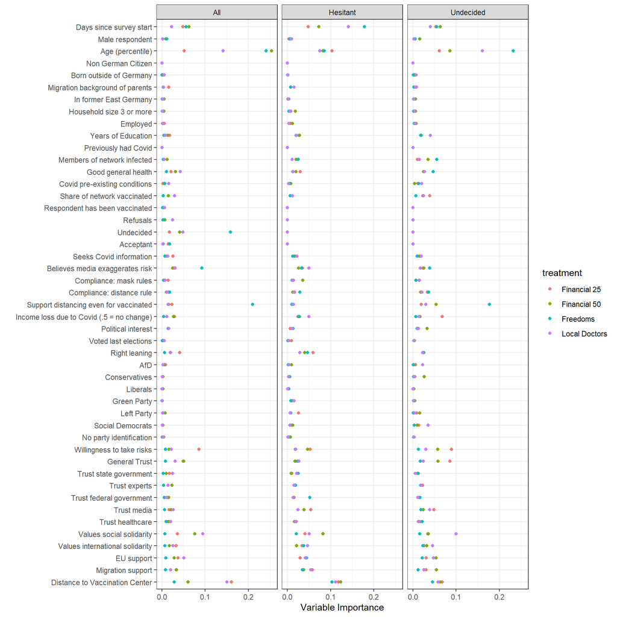

```r
what_matters <-
  list(All = cf_all, Undecided = cf_undecided, Hesitant = cf_hesitant) %>%
  lapply(function(res)
    lapply(res, function(j) j$var_imp %>% t %>% data.frame) %>%
      bind_rows %>% mutate(treatment = names(cf_all)) %>%
      gather(covariate, "value", - treatment)) %>% bind_rows(.id = "group")

what_matters_plot <-
  what_matters  %>%
  mutate(
    covariate = factor(covariate,   rev(var_list$new_name), rev(var_list$label)),
    treatment = factor(treatment, treatment_levels_diff, treatment_labels)) %>%
    ggplot(aes(value, covariate, color = treatment)) +
    geom_point()+
    scale_x_continuous(name="Variable Importance")+
    theme_bw() + facet_wrap(~group) + ylab(" ")

what_matters_plot
```

```r
pdf(fig_3_path, width = 9, height = 9)
  what_matters_plot
dev.off()
```

### Variation across ntiles

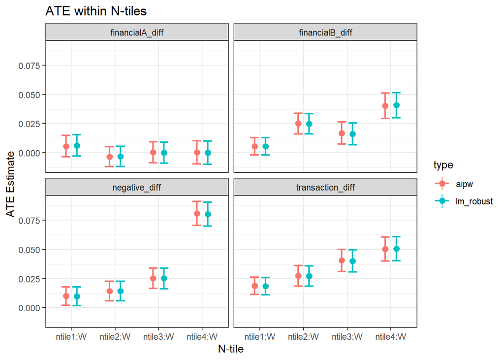

```r
# plot
lapply(cf_all, function(j)  j$ntile_estimates) %>%
  bind_rows(.id = "treatment") %>%
  ggplot() +
  geom_pointrange(
    aes(x = term, y = estimate, ymax = conf.high, ymin = conf.low, color = type),
    size = 0.5,
    position = position_dodge(width = .5)) +
  geom_errorbar(aes(x = term, ymax = conf.high, ymin = conf.low, color = type),
                width = 0.4,
                size = 0.75,
                position = position_dodge(width = .5)) +
  theme_bw() +
  labs(x = "N-tile", y = "ATE Estimate", title = "ATE within N-tiles") +
  facet_wrap(~treatment)
```

### Graph heterogeneous effects

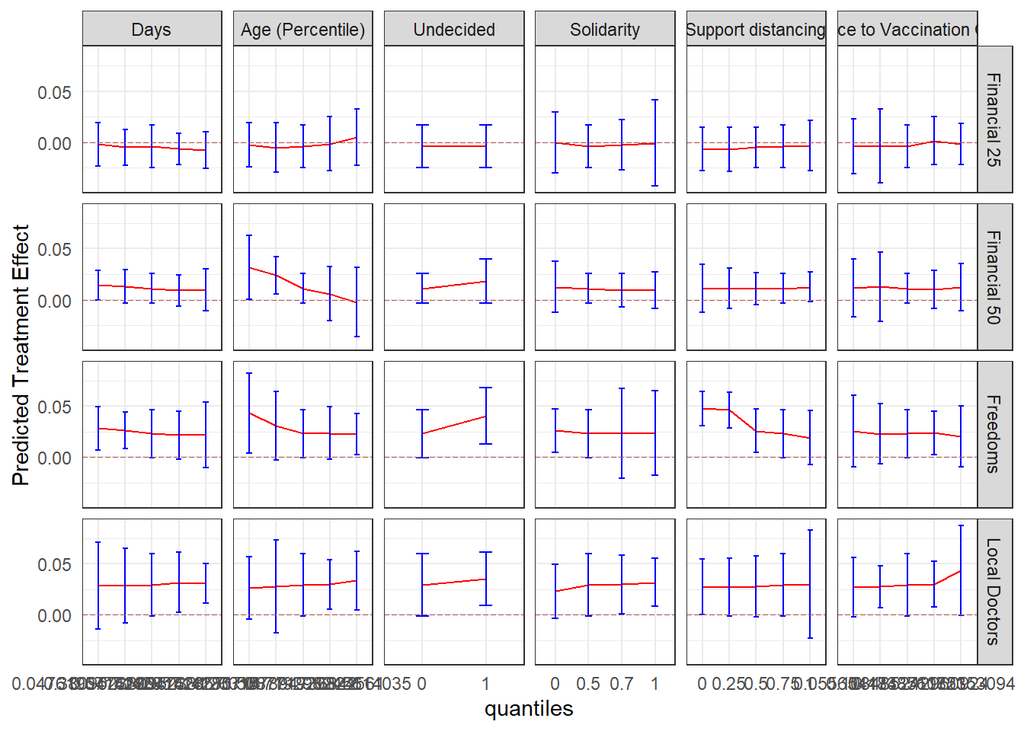

```r
vars <- c("days", "age2", "undecided", "solidarity", "support.distance","distance_km")

all_marginals <-
  lapply(vars, function(x)
         lapply(cf_all , function(model)
           fitted_vals(x, model = model) %>%
             mutate(var = x)
           ) %>% bind_rows(.id = "treatment")) %>%
  bind_rows %>%
  mutate(var = factor(var, vars, c("Days", "Age (Percentile)", "Undecided", "Solidarity", "Support distancing","Distance to Vaccination Center")),
         treatment =
           factor(treatment,treatment_levels_diff, treatment_labels),
var_of_interest =
  factor(as.numeric(paste(var_of_interest)),
sort(unique(as.numeric(paste(var_of_interest))))))

figure_4 <-

all_marginals %>%
  mutate(ymin_val = tauhat-1.96*se) %>%
  mutate(ymax_val = tauhat+1.96*se) %>%
  ggplot()  +
  geom_line(aes_string(x="var_of_interest", y="tauhat", group = 1), color="red") +
  geom_errorbar(aes_string(x="var_of_interest",ymin="ymin_val", ymax="ymax_val", width=.2),color="blue") +
  geom_hline(yintercept=0, linetype="longdash", lwd=0.35, colour = "#B55555") +
  ylab("Predicted Treatment Effect") +
  theme_bw() +
  theme(axis.ticks = element_blank()) +
  facet_grid(treatment ~ var, scales = "free_x") +
  xlab("quantiles")

figure_4
```

```r
pdf(fig_4_path, width = 8, height = 6)
figure_4
dev.off()
```

### Best linear projections

Using causal forests functions:

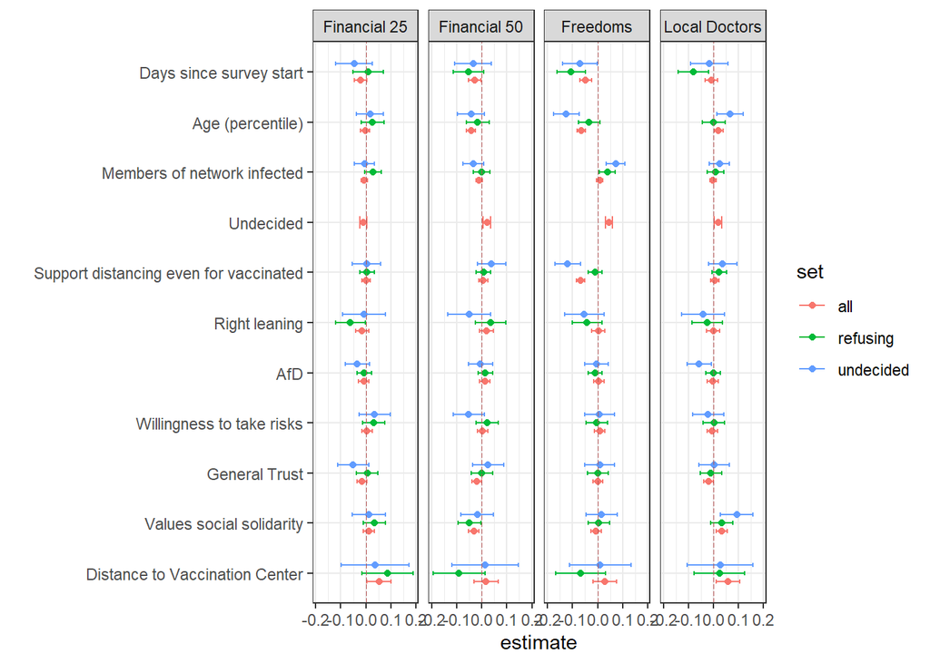

```r
blps <-
lapply(
  list(all = cf_all, undecided = cf_undecided, refusing = cf_hesitant),
  function(set) lapply(set,  function(model)
       lapply(1:length(covariate_names), function(i)
           best_linear_projection(model$cf, model$X[,i]) %>%
             tidy  %>%
         dplyr::filter(term!="(Intercept)") %>%
         dplyr::mutate(var = covariate_names[i])) %>%
        bind_rows()) %>%
    bind_rows(.id = "treatment")) %>% bind_rows(.id = "set") %>%
  dplyr::mutate(treatment = factor(treatment, treatment_levels_diff, treatment_labels))


# importance
top <- 3
most_common <- c(lapply(cf_all, function(j) names(j$var_imp[1:top])) %>% bind_rows(.id = "treatment") %>% unlist(),
lapply(cf_undecided, function(j) names(j$var_imp[1:top])) %>% bind_rows(.id = "treatment") %>% unlist(),
lapply(cf_hesitant, function(j) names(j$var_imp[1:top])) %>% bind_rows(.id = "treatment") %>% unlist()) %>% unique()

# add in promised measures from PAP

most_common <- unique(c(most_common, "AfD", "risk", "trust"))
blps_plot <-
  blps %>% dplyr::filter(var %in% most_common) %>%
  mutate(var = factor(var,   rev(var_list$new_name), rev(var_list$label))) %>%
    ggplot(aes(estimate, var, color = set)) +
    geom_point(position=position_dodge(width = .5)) +
    geom_errorbar(aes(xmin = estimate - 1.96*std.error, xmax = estimate + 1.96*std.error), width = .25,  position=position_dodge(width = .5)) +
  facet_grid(~treatment) +
  geom_vline(xintercept=0, linetype="longdash", lwd=0.35, size=0.75, colour = "#B55555") +
  theme_bw()  +
  ylab("")



blps_plot
```

```r
pdf(blps_plot_path, height = 6, width = 9)
blps_plot
dev.off()
```

Using `lm_robust`:

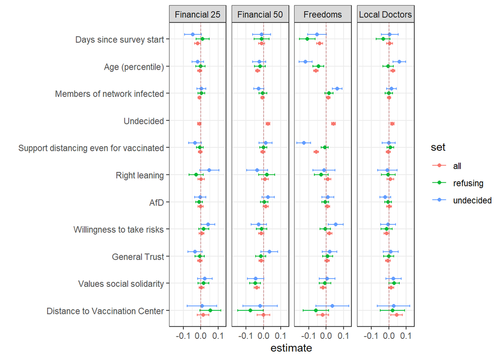

```r
lm_interactions <-
lapply(
  list(all = df, undecided = dplyr::filter(df, undecided==1), refusing = dplyr::filter(df, refusing==1)),
  function(dff) lapply(treatment_levels_diff,  function(X)
       lapply(1:length(covariate_names), function(i)
           lm_robust(as.formula(paste("outcome_diff~", X, "*", covariate_names[i])), data = dff) %>%
             tidy  %>% slice(4) %>%
         mutate(var = covariate_names[i], treatment = X)) %>%
        bind_rows()) %>%
    bind_rows()) %>% bind_rows(.id = "set") %>%
  mutate(treatment = factor(treatment, treatment_levels_diff, treatment_labels))

lm_plot <-
  lm_interactions %>% dplyr::filter(var %in% most_common) %>%
  dplyr::filter(!(var == "undecided" & set == "undecided")) %>%
  dplyr::filter(!(var == "refusing" & set == "refusing")) %>%
  mutate(var = factor(var,   rev(var_list$new_name), rev(var_list$label))) %>%
    ggplot(aes(estimate, var, color = set)) +
    geom_point(position=position_dodge(width = .5)) +
    geom_errorbar(aes(xmin = conf.low, xmax = conf.high), width = .25,  position=position_dodge(width = .5)) +
  facet_grid(~treatment) +
  geom_vline(xintercept=0, linetype="longdash", lwd=0.35, size=0.75, colour = "#B55555") +
  theme_bw()  +
  ylab("")

lm_plot
```

```r
pdf(lm_plot_path, height = 6, width = 9)
lm_plot
dev.off()
```

### Marginal effects for undecided

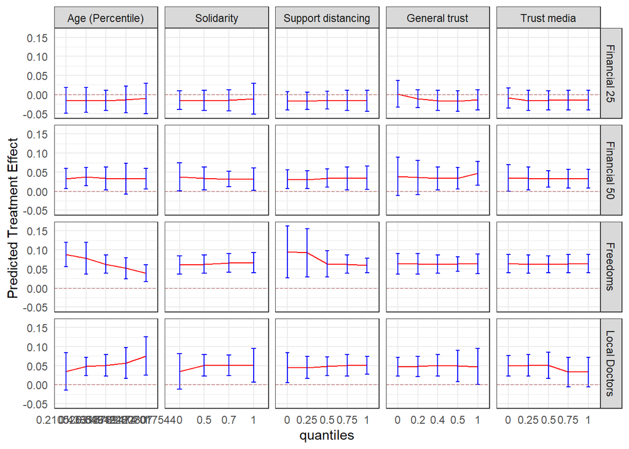

```r
v2 <- c("age2",  "solidarity", "support.distance", "trust", "trust.media")

v2labs <- c("Age (Percentile)",  "Solidarity", "Support distancing","General trust", "Trust media")


figure_8  <-

  lapply(v2, function(x)
         lapply(cf_undecided , function(model)
           fitted_vals(x, model = model) %>%
             mutate(var = x)
           ) %>% bind_rows(.id = "treatment")) %>%
  bind_rows %>%
  mutate(var = factor(var, v2, v2labs),
         treatment = factor(treatment,
                            paste0(treatment_levels_diff),
                            treatment_labels),
var_of_interest =
  factor(as.numeric(paste(var_of_interest)),
sort(unique(as.numeric(paste(var_of_interest)))))) %>%
  mutate(ymin_val = tauhat-1.96*se) %>%
  mutate(ymax_val = tauhat+1.96*se) %>%
  ggplot()  +
  geom_line(aes_string(x="var_of_interest", y="tauhat", group = 1), color="red") +
  geom_errorbar(aes_string(x="var_of_interest",ymin="ymin_val", ymax="ymax_val", width=.2),color="blue") +
  geom_hline(yintercept=0, linetype="longdash", lwd=0.35, colour = "#B55555") +
  ylab("Predicted Treatment Effect") +
  theme_bw() +
  theme(axis.ticks = element_blank()) +
  facet_grid(treatment ~ var, scales = "free_x") +
  xlab("quantiles")


figure_8
```

```r
pdf(undecided_cf_path, height = 8, width = 8)
figure_8
dev.off()
```

### Predictions by age

```r
M <- lm_robust(outcome_diff~age2*negative_diff*transaction_diff, data = df)

# Different for old
linearHypothesis(M, "negative_diff + age2:negative_diff = transaction_diff + age2:transaction_diff")
```

```
Linear hypothesis test

Hypothesis:
negative_diff - transaction_diff  + age2:negative_diff - age2:transaction_diff = 0

Model 1: restricted model
Model 2: outcome_diff ~ age2 * negative_diff * transaction_diff

  Res.Df Df  Chisq Pr(>Chisq)
1  20493
2  20492  1 84.622  < 2.2e-16 ***
---
Signif. codes:  0 '***' 0.001 '**' 0.01 '*' 0.05 '.' 0.1 ' ' 1
```

```r
# Different for young
linearHypothesis(M, "negative_diff  = transaction_diff ")
```

```
Linear hypothesis test

Hypothesis:
negative_diff - transaction_diff = 0

Model 1: restricted model
Model 2: outcome_diff ~ age2 * negative_diff * transaction_diff

  Res.Df Df  Chisq Pr(>Chisq)
1  20493
2  20492  1 60.115  8.945e-15 ***
---
Signif. codes:  0 '***' 0.001 '**' 0.01 '*' 0.05 '.' 0.1 ' ' 1
```

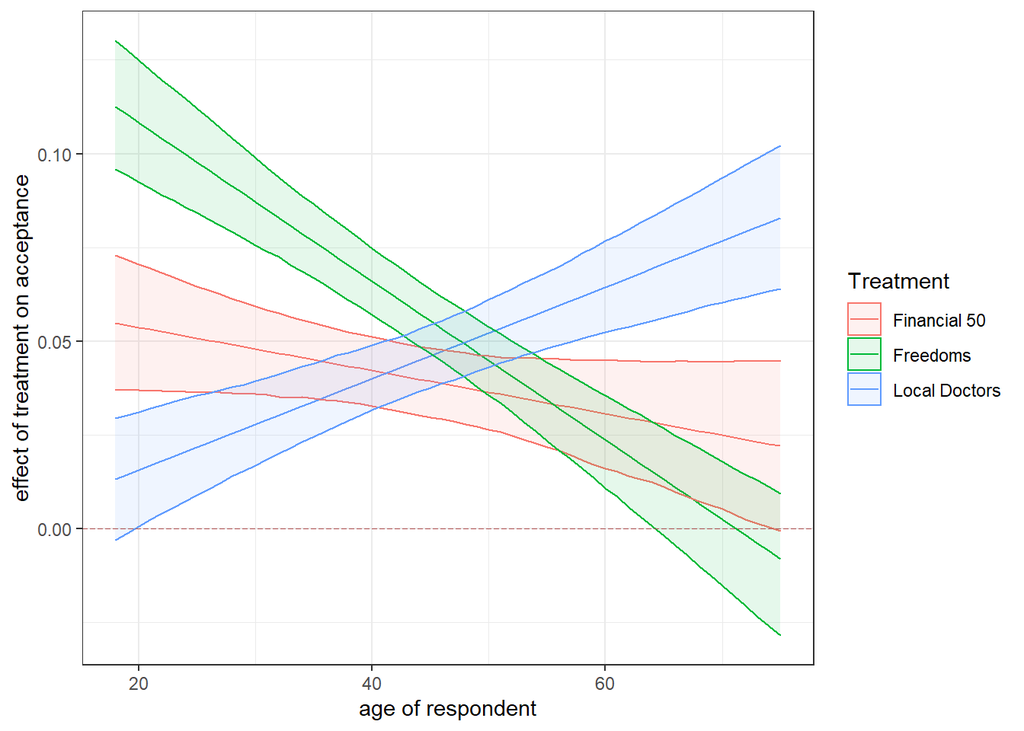

```r
M0 <- lm(outcome_diff~age2*negative_diff*transaction_diff*financialB_diff, data = df)
M1 <- lm(outcome_diff~age*negative_diff*transaction_diff*financialB_diff, data = df)
M2 <- lm(outcome_diff~age*negative_diff*transaction_diff*financialB_diff, data = dplyr::filter(df, status == "Undecided"))

dff <- list(
  Freedoms = interplot(m = M2, var1 = "negative_diff", var2 = "age", plot = FALSE),
  'Local Doctors' = interplot(m = M2, var1 = "transaction_diff", var2 = "age", plot = FALSE),
    'Financial 50' = interplot(m = M2, var1 = "financialB_diff", var2 = "age", plot = FALSE)) %>% bind_rows(.id = "Treatment")


age_plot <- dff %>%
ggplot(aes(x=age, y=coef, colour=Treatment)) + #geom_point() +
  geom_line() +
  geom_ribbon(aes(ymin=lb, ymax=ub, fill=Treatment), alpha=0.1) +
  geom_hline(yintercept=0, linetype="longdash", lwd=0.35, size=0.75, colour = "#B55555") +
  ylab("effect of treatment on acceptance") +
  xlab("age of respondent")  +
  theme_bw()


age_plot
```

```r
pdf(age_fig_path, width = 7, height = 4)
age_plot
dev.off()
```

### Predictions by distance

```r
M <- lm_robust(outcome_diff~distance_km*negative_diff*transaction_diff, data = df)
# Different for old
linearHypothesis(M, "negative_diff + distance_km:negative_diff = transaction_diff + distance_km:transaction_diff")
```

```
Linear hypothesis test

Hypothesis:
negative_diff - transaction_diff  + distance_km:negative_diff - distance_km:transaction_diff = 0

Model 1: restricted model
Model 2: outcome_diff ~ distance_km * negative_diff * transaction_diff

  Res.Df Df Chisq Pr(>Chisq)
1  20493
2  20492  1 7.811   0.005193 **
---
Signif. codes:  0 '***' 0.001 '**' 0.01 '*' 0.05 '.' 0.1 ' ' 1
```

```r
# Different for young
linearHypothesis(M, "negative_diff  = transaction_diff ")
```

```
Linear hypothesis test

Hypothesis:
negative_diff - transaction_diff = 0

Model 1: restricted model
Model 2: outcome_diff ~ distance_km * negative_diff * transaction_diff

  Res.Df Df  Chisq Pr(>Chisq)
1  20493
2  20492  1 1.6787     0.1951
```

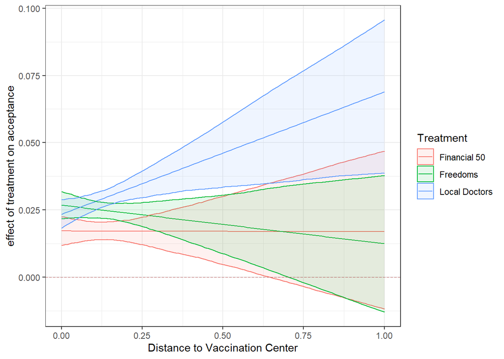

```r
M1 <- lm(outcome_diff~distance_km*negative_diff*transaction_diff*financialB_diff, data = df)
M2 <- lm(outcome_diff~distance_km*negative_diff*transaction_diff*financialB_diff, data = dplyr::filter(df, status == "Undecided"))

dff <- list(
  Freedoms = interplot(m = M1, var1 = "negative_diff", var2 = "distance_km", plot = FALSE),
  'Local Doctors' = interplot(m = M1, var1 = "transaction_diff", var2 = "distance_km", plot = FALSE),
    'Financial 50' = interplot(m = M1, var1 = "financialB_diff", var2 = "distance_km", plot = FALSE)) %>% bind_rows(.id = "Treatment")


distance_plot <- dff %>%
ggplot(aes(x=distance_km, y=coef, colour=Treatment)) + #geom_point() +
  geom_line() +
  geom_ribbon(aes(ymin=lb, ymax=ub, fill=Treatment), alpha=0.1) +
  geom_hline(yintercept=0, linetype="longdash", lwd=0.35, size=0.75, colour = "#B55555") +
  ylab("effect of treatment on acceptance") +
  xlab("Distance to Vaccination Center")  +
  theme_bw()


distance_plot
```

```r
pdf(distance_plot, width = 7, height = 4)
distance_plot
dev.off()
```

### Export Fig 2

Fig 2 in the paper combines three panels. Exported here.

```r
fig_2_ABC <- ggarrange(lm_plot, age_plot, distance_plot,
                    labels = c("A", "B", "C"),
                    ncol = 1, nrow = 3)
# figure_13
pdf(fig_2_ABC_path, width = 8, height = 15)
fig_2_ABC
dev.off()
```

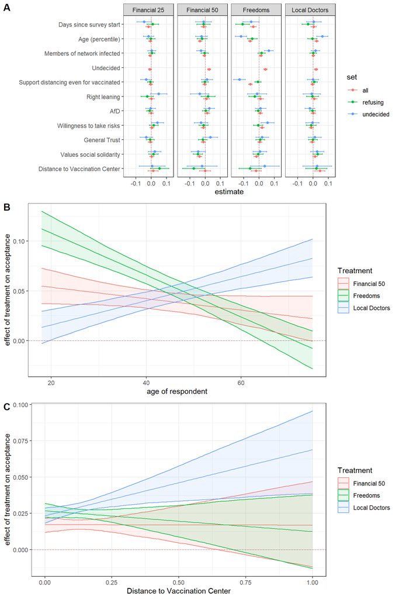

```r
fig_2_ABC
```